# Enhancing Chandrayaan3 - Moon Image Quality using Image Processing

1.RESIZE AND SACALING OF IMAGE 2.HISTOGRAM EQUALIZATION 3.EDGE DETECTION OF AN IMAGE 4.MORPHOLOGICAL OPERATIONS 5.IMAGE SEGMENTATION 6.FEATURE EXTRACTION 7.IMAGE STACKING

Read a custom Color Image and convert the image to Grayscale Image

# Required Libraries

open-cv: Open cv is a huge open source library for computer vision, machine learning and image processing. It can process images and videos to identify objects, faces, or even the handwritting of a human. When it is integrate dwith various libraries such as "numpy", whatever operations can be done in Numpy, will be combined with open cv.

Numpy: NumPy is a python library used for working with arrays. It also has functions for working in domain of linear algebra, fouriar transform and matrices. NumPy standa for Numerical Python.

# EXERCISE 1: READING THE IMAGE(Aug 2023)

1.Python has important tools for image processing, such as ope-cv and matplotlib. 2.First of all import the important libraries like cv2 and numpy. 3.Use the cv2.imread function to read the image. Accurate image path must be give within the argument. The image must either be uploaded on the jupyter file and then the name of the image can be given directly, or the direct path where the image is present. 4.Use the print function to pint the oixels of the image in matrix form. Digital image is a collection of pixels represented in the form of numpy arrays.

```python
import cv2 as cv  ##cv2. imread() method loads an image from the specified file
```

```python
img=cv.imread("C:\\Users\\91938\\OneDrive\\Desktop\\chandrayaan\\moon1.jpeg") ##This is image path
print(img)
```

[output not shown]

```python
img.shape  ## no of rows and coloumns
```

```python
print("height:",img.shape[0])  ##Indexing
```

[output not shown]

```python
print("width:",img.shape[1])
```

```python
print(img.size)
```

[output not shown]

```python
#accessing pixel of an image
```

```python
print(img[10,249])
```

concept of channels in an image Grayscale image A grayscale image is simply one in which the only colors are shades of gray it have 256 possible different shades of gray from black to white

```python
#converting a color image to gray image
```

```python
#concept of channels in an image
#gray scale image
```

```python
image=cv.imread("C:\\Users\\91938\\OneDrive\\Desktop\\chandrayaan\\moon1.jpeg")
```

```python
 ##cv2. cvtColor() method is used to convert an image from one color space to another
gray=cv.cvtColor(image,cv.COLOR_BGR2GRAY)

print(gray)
```

[output not shown]

```python
print(gray.shape)
```

# EXPERIMENT 2: RESIZE AND SACALING OF IMAGE(aug 2023)

#1. Image resizing refers to the scaling of images. Scaling comes in handy in many image processing as well as machine learning applications. It helps in reducing the number of pixels from an image and that has several advantages e.g. It can reduce the time of training. It also helps in zooming in images. Many times we need to resize the image i.e. either shrink it or scale up to meet the size requirements. OpenCV provides us several interpolation methods for resizing an image. Choice of Interpolation Method for Resizing: cv2.INTER_AREA: This is used when we need to shrink an image. cv2.INTER_CUBIC: This is slow but more efficient. cv2.INTER_LINEAR: This is primarily used when zooming is required. This is the default interpolation technique in OpenCV.

# SYNTAX: -cv2.resize(src, dsize[, dst[, fx[, fy[, interpolation]]]])

```
 src: -source/input image
 dsize: -desired size for the output image
 fx: -scale factor along the horizontal axis
 fy: -scale factor along the vertical axis
```

# Resize the image changing only Height

import cv2 as cv img=cv.imread("Downloads\color.jpeg") print("original image:",img.shape)

height =200 width= img.shape[0] dim=(width,height)

# resize the image

resized_image= cv.resize(img,dim,interpolation = cv.INTER_CUBIC) print("resized dimension:",resized_image.shape) cv.imshow("original image",img) cv.imshow("resized image",resized_image) cv.waitKey(0) cv.destroyAllWindows()

# Upscaling the image

Increasing the dimensions of the image.

```python
#upscaling
import cv2 as cv
img=cv.imread("C:\\Users\\91938\\OneDrive\\Desktop\\chandrayaan\\moon1.jpeg")
print("original image:",img.shape)
scale_perc=250

width = int(img.shape[1]*scale_perc/100)
height= int(img.shape[0]*scale_perc/100)

dim=(width,height)
#resize the image
resized_image= cv.resize(img,dim,interpolation = cv.INTER_CUBIC)
print("resized dimension:",resized_image.shape)
cv.imshow("original image",img)
cv.imshow("resized image",resized_image)
cv.waitKey(0)
cv.destroyAllWindows()
```

# Downscaling the images:

Decreasing the dimensions of the image

```python
#downscaling
import cv2 as cv
img=cv.imread("C:\\Users\\91938\\OneDrive\\Desktop\\chandrayaan\\moon1.jpeg")
print("original image:",img.shape)
scale_perc=40

width = int(img.shape[1]*scale_perc/100)
height= int(img.shape[0]*scale_perc/100)

dim=(width,height)
#resize the image
resized_image= cv.resize(img,dim,interpolation = cv.INTER_CUBIC)
print("resized dimension:",resized_image.shape)
cv.imshow("original image",img)
cv.imshow("resized image",resized_image)
cv.waitKey(0)
cv.destroyAllWindows()
```

# HISTOGRAM EQUALIZATION(AUG 2023)

SYNTAX: -matplotlib.pyplot.hist(x, bins=None, range=None, density=False, weights=None, cumulative=False, bottom=None, histtype=’bar’, align=’mid’, orientation=’vertical’, rwidth=None, log=False, color=None, label=None, stacked=False, *, data=None, **kwargs) The numpy.ravel() functions returns contiguous flattened array SYNTAX: -numpy.ravel(array, order = 'C') Where array :Input array order: C order means that operating row-rise on the array will be slightly quicker F order means that column-wise operations will be faster

# plotting histograms

a histogram is representation of the distribution of numerical data, where the data are binned and the count for each bin is represented

# plotting histograms #short way:use matplotlib plotting function #long way:use opencv drawing functions

# Using Matplotlib

in addition to Open-CV, we will also import NumPy and matplotlib to demonstarte the histogram equalization

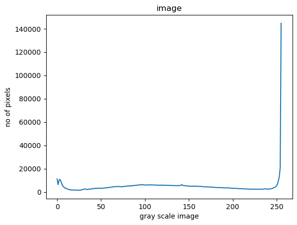

```python
import numpy as np
import cv2 as cv
from matplotlib import pyplot as plt
img=cv.imread("C:\\Users\\91938\\OneDrive\\Desktop\\chandrayaan\\moon1.jpeg",0)
plt.show()

#FIND THE HISTOGRAM

##cv2.calcHist(images, channels, mask, histSize, ranges[, hist[, accumulate]]) images
gray_image=cv.calcHist([img],[0],None,[256],[0,256])  ##Histogram Calculation
plt.plot(gray_image)
plt.title("image")
plt.ylabel("no of pixels")  ## used to set the label for the y-axis
plt.xlabel("gray scale image") ## used to set the label for the x-axis
plt.show()
```

# using opencv

cv.calcHist() function can be used to compute image histograms.

SYNTAX: -calcHist(sourceimage, channels, mask, histSize, ranges ) Where 1)images: source image of type uint8 or float32. it should be given in as a list, ie, [gray_img]. 2)channels: it is also given in as a list []. It the index of channel for which we calculate histogram. 3)mask: mask image. To find histogram of full image, it is set as None. 4)histSize: this represents our BIN count. 5)ranges: Normally, it is [0,256]. enumerate() allows us to iterate through a sequence cv.equalizeHist() Histogram equalization improves the contrast of an image, in order to stretch out the intensty range. SYNTAX: -equalizeHist(Source Matrix, Destination Matrix)

[figure not shown]

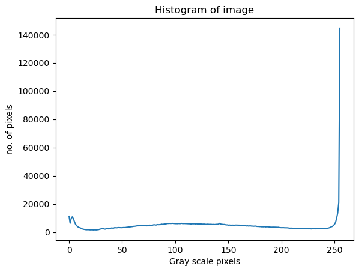

```python
import numpy as np
import cv2 as cv
from matplotlib import pyplot as plt

img= cv.imread("C:\\Users\\91938\\OneDrive\\Desktop\\chandrayaan\\moon1.jpeg",0)

plt.imshow(img, cmap="gray")
plt.show()

gray_image=cv.calcHist([img],[0],None,[256],[0,256])
plt.plot(gray_image)

plt.title("Histogram of image")
plt.ylabel("no. of pixels")
plt.xlabel("Gray scale pixels")
plt.show()
```

[figure not shown]

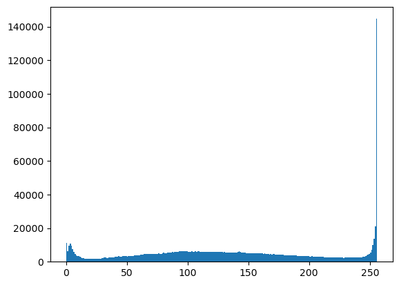

```python
import numpy as np
import cv2 as cv
from matplotlib import pyplot as plt
img = cv.imread("C:\\Users\\91938\\OneDrive\\Desktop\\chandrayaan\\moon1.jpeg",0)
plt.imshow(img,cmap="gray")  ##cmap stands for colormap and it's a colormap instance colormap name
plt.show()

##used to change a 2-dimensional array or a multi-dimensional array into a contiguous flattened array
plt.hist(img.ravel(),256,[0,256]);
plt.show()
```